# Midterm

Kellen Stark

2023-02-19

# Midterm (Due Sunday 2/19/2023 at 11:55 pm)

Please submit your `.Rmd` and `.html` files in Sakai. If you are working together, both people should submit the files.

## 60 / 60 points total

## Please Note

I will take off points (-5 points for each section) if you don’t add observations and notes in your RMarkdown document. I want you to think and reason through your analysis, even if they are preliminary thoughts.

## Define Your Research Question (10 points)

> *Define your research question below. What about the data interests you? What is a specific question you want to find out about the data?*

> My data were collected from a data file called Hotel Reservations. I was surprised at how much data were collected on hotel bookings, including the number of adults, children, meal plan, cancellations, etc. This summed up to 19 separate variables based on hotel reservations total. I was curious to see if there was a difference in the number of cancellations based on how early a reservation was made.

> *Given your question, what is your expectation about the data?*

> My assumption is the greater ahead of time a person reserves a room, the greater the chance they will cancel. I am assuming this occurs because there are greater costs to canceling a reservation the closer to the date of the booking ( think cancellation fee, less time to find another hotel, etc). The earlier a reservation is made, the less chance of additional costs if the reservation is canceled. This reasoning can’t be shown in the data given, but is my best guess for why this might occur.

## Loading the Data (10 points)

> *Load the data below and use `dplyr::glimpse()` or `skimr::skim()` on the data. You should upload the data file into the `data` directory.*

```r
reserve <-read.csv("Data/Hotel_Reservations.csv")

glimpse(reserve)
```

```
## Rows: 36,275
## Columns: 19
## $ Booking_ID                           <chr> "INN00001", "INN00002", "INN00003…
## $ no_of_adults                         <int> 2, 2, 1, 2, 2, 2, 2, 2, 3, 2, 1, …
## $ no_of_children                       <int> 0, 0, 0, 0, 0, 0, 0, 0, 0, 0, 0, …
## $ no_of_weekend_nights                 <int> 1, 2, 2, 0, 1, 0, 1, 1, 0, 0, 1, …
## $ no_of_week_nights                    <int> 2, 3, 1, 2, 1, 2, 3, 3, 4, 5, 0, …
## $ type_of_meal_plan                    <chr> "Meal Plan 1", "Not Selected", "M…
## $ required_car_parking_space           <int> 0, 0, 0, 0, 0, 0, 0, 0, 0, 0, 0, …
## $ room_type_reserved                   <chr> "Room_Type 1", "Room_Type 1", "Ro…
## $ lead_time                            <int> 224, 5, 1, 211, 48, 346, 34, 83, …
## $ arrival_year                         <int> 2017, 2018, 2018, 2018, 2018, 201…
## $ arrival_month                        <int> 10, 11, 2, 5, 4, 9, 10, 12, 7, 10…
## $ arrival_date                         <int> 2, 6, 28, 20, 11, 13, 15, 26, 6, …
## $ market_segment_type                  <chr> "Offline", "Online", "Online", "O…
## $ repeated_guest                       <int> 0, 0, 0, 0, 0, 0, 0, 0, 0, 0, 0, …
## $ no_of_previous_cancellations         <int> 0, 0, 0, 0, 0, 0, 0, 0, 0, 0, 0, …
## $ no_of_previous_bookings_not_canceled <int> 0, 0, 0, 0, 0, 0, 0, 0, 0, 0, 0, …
## $ avg_price_per_room                   <dbl> 65.00, 106.68, 60.00, 100.00, 94.…
## $ no_of_special_requests               <int> 0, 1, 0, 0, 0, 1, 1, 1, 1, 3, 0, …
## $ booking_status                       <chr> "Not_Canceled", "Not_Canceled", "…
```

> *If there are any quirks that you have to deal with `NA` coded as something else, or it is multiple tables, please make some notes here about what you need to do before you start transforming the data in the next section.*

> Luckily there is no missing data, so no additional adjustments needed to be made.

> **Make sure your data types are correct!**

## Transforming the data (15 points)

> *If the data needs to be transformed in any way (values recoded, pivoted, etc), do it here. Examples include transforming a continuous variable into a categorical using `case_when()`, etc.*

> Based on my question of interest, I will only be focusing on the variables

> **`lead_time`, numeric:** How far ahead the room was reserved in days. I will transform this into a categorical variable as well.

> **`booking_status`, categorical:** whether the reservation was cancelled or not

> **`market_segment_type`, categorical:** How/ Why the reservation was booked. This includes aviation, complementary, corporate, offline and online. I will use this variable further towards the end, and will only focus on the online/offline portion.

> The first transformation I will make is mutating the `lead_time` variable into a categorical variable. The range of the values increase after `lead_time` is greater than 100 as the number of observations decreases significantly. It is also important to note that the way each category was separated was rather arbitrary. I also included the alphabet in front of each category name because I could not get them in the appropriate order otherwise.

```r
reserve <- reserve %>% mutate( lead_cat = case_when( lead_time >= 0 &
                                            lead_time < 20 ~ "a[0,20)",
                                          lead_time >= 20 &
                                            lead_time < 40 ~ "b[20,40)",
                                          lead_time >= 40 &
                                            lead_time < 60 ~ "c[40,60)",
                                          lead_time >= 60 &
                                            lead_time < 80 ~ "d[60,80)",
                                          lead_time >= 80 &
                                            lead_time < 100 ~ "e[80,100)",
                                          lead_time >= 100 &
                                            lead_time < 200 ~ "f[100,200)",
                                          lead_time >= 200 &
                                            lead_time < 300 ~ "g[200,300)",
                                          lead_time >= 300 ~ "h[300, inf)"

                                          ))

reserve <- reserve %>% filter( market_segment_type %in% c("Offline", "Online")) #This will be used to see if reserving offline or online makes any difference.
```

> *Show your transformed table here.* Use tools such as `glimpse()`, `skim()` or `head()` to illustrate your point.

> As seen below, `lead_cat` is a catagorical variable of `lead_time`, with the categories  
> a[0,20), b[20,40), c[40,60), d[60,80), e[80,100), f[100,200), g[200,300), h[300, inf)

```r
glimpse(reserve)
```

```
## Rows: 33,742
## Columns: 20
## $ Booking_ID                           <chr> "INN00001", "INN00002", "INN00003…
## $ no_of_adults                         <int> 2, 2, 1, 2, 2, 2, 2, 2, 3, 2, 1, …
## $ no_of_children                       <int> 0, 0, 0, 0, 0, 0, 0, 0, 0, 0, 0, …
## $ no_of_weekend_nights                 <int> 1, 2, 2, 0, 1, 0, 1, 1, 0, 0, 1, …
## $ no_of_week_nights                    <int> 2, 3, 1, 2, 1, 2, 3, 3, 4, 5, 0, …
## $ type_of_meal_plan                    <chr> "Meal Plan 1", "Not Selected", "M…
## $ required_car_parking_space           <int> 0, 0, 0, 0, 0, 0, 0, 0, 0, 0, 0, …
## $ room_type_reserved                   <chr> "Room_Type 1", "Room_Type 1", "Ro…
## $ lead_time                            <int> 224, 5, 1, 211, 48, 346, 34, 83, …
## $ arrival_year                         <int> 2017, 2018, 2018, 2018, 2018, 201…
## $ arrival_month                        <int> 10, 11, 2, 5, 4, 9, 10, 12, 7, 10…
## $ arrival_date                         <int> 2, 6, 28, 20, 11, 13, 15, 26, 6, …
## $ market_segment_type                  <chr> "Offline", "Online", "Online", "O…
## $ repeated_guest                       <int> 0, 0, 0, 0, 0, 0, 0, 0, 0, 0, 0, …
## $ no_of_previous_cancellations         <int> 0, 0, 0, 0, 0, 0, 0, 0, 0, 0, 0, …
## $ no_of_previous_bookings_not_canceled <int> 0, 0, 0, 0, 0, 0, 0, 0, 0, 0, 0, …
## $ avg_price_per_room                   <dbl> 65.00, 106.68, 60.00, 100.00, 94.…
## $ no_of_special_requests               <int> 0, 1, 0, 0, 0, 1, 1, 1, 1, 3, 0, …
## $ booking_status                       <chr> "Not_Canceled", "Not_Canceled", "…
## $ lead_cat                             <chr> "g[200,300)", "a[0,20)", "a[0,20)…
```

> *Are the values what you expected for the variables? Why or Why not?*

> It looks like separating `lead_time` into categorical variables was a success, as the numbers in `lead_time` fit appropriately within the catagories of `lead_cat`.

## Visualizing and Summarizing the Data (15 points)

> *Use `group_by()` and `summarize()` to make a summary of the data here. The summary should be relevant to your research question*

> Although summarize helped, I used tabyl with the help of the internet. (https://cran.r-project.org/web/packages/janitor/vignettes/tabyls.html) to help produce a table that shows both the counts and percentages of `lead_cat` by `booking_status.` You can also see that in order to summarize to work, I had to turn `booking_status` into a binary variable, with 1 - “Not Canceled”. However I did not need to do this using the tabyl function.

```r
reserve <- reserve %>% mutate(booking1 = 1*(booking_status == "Not_Canceled"))

reserve %>% group_by(lead_cat) %>% summarize(mean = mean(booking1))
```

```
## # A tibble: 8 × 2
##   lead_cat     mean
##   <chr>       <dbl>
## 1 a[0,20)     0.863
## 2 b[20,40)    0.773
## 3 c[40,60)    0.766
## 4 d[60,80)    0.710
## 5 e[80,100)   0.693
## 6 f[100,200)  0.502
## 7 g[200,300)  0.278
## 8 h[300, inf) 0.185
```

```r
reserve %>%  tabyl(booking_status, lead_cat)%>%
adorn_totals("col") %>%
  adorn_percentages("col") %>%
  adorn_pct_formatting(digits = 1) %>%
  adorn_ns %>%
  gt()
```

| booking_status | a[0,20) | b[20,40) | c[40,60) | d[60,80) | e[80,100) | f[100,200) | g[200,300) | h[300, inf) | Total |
| --- | --- | --- | --- | --- | --- | --- | --- | --- | --- |
| Canceled | 13.7% (1089) | 22.7% (1058) | 23.4% (859) | 29.0% (914) | 30.7% (734) | 49.8% (3886) | 72.2% (2174) | 81.5% (914) | 34.5% (11628) |
| Not_Canceled | 86.3% (6852) | 77.3% (3593) | 76.6% (2811) | 71.0% (2241) | 69.3% (1656) | 50.2% (3917) | 27.8% (836) | 18.5% (208) | 65.5% (22114) |

> *What are your findings about the summary? Are they what you expected?*

> Based on the percentages, It *appears* that the ealier the reservation, the greater the chance that the reservation will be canceled. This is what I expected overall, although it is difficult just by the summary alone how significant it is or how it looks visually.

> *Make at least two plots that help you answer your question on the transformed or summarized data. Use scales and/or labels to make each plot informative.*

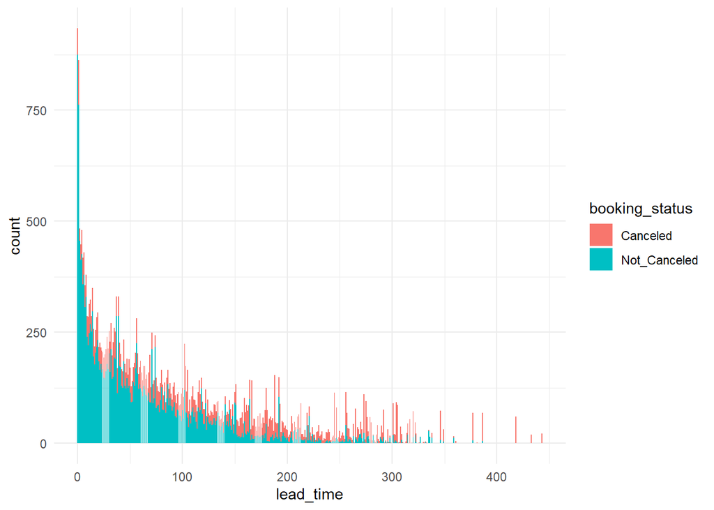

```r
ggplot(reserve, aes( x = lead_time, fill = booking_status)) +
  geom_bar() +
  theme_minimal()
```

>This graph gives a better view of the change in distribution of the booking_status based on lead_cat.

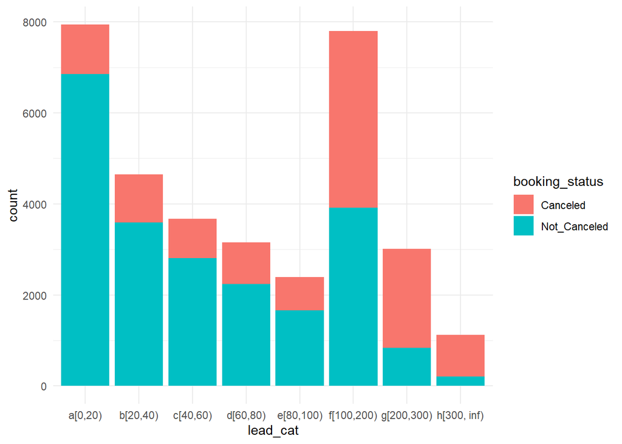

```r
ggplot(reserve, aes( x = lead_cat, fill = booking_status)) +
  geom_bar() +
  theme_minimal()
```

> The final graph shows the distribution looks at the distribution of booking_status by lead_time. This density plot best shows the distribution of booking_status, but doesn’t take into account the observations. For instance, there are very few observations beyond 400 days relative to the amount of observations viewed in between 0 and 100 days.

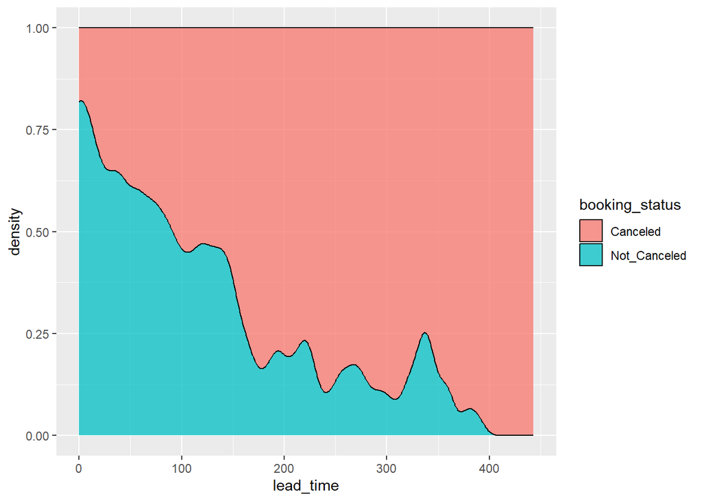

```r
ggplot(reserve, aes(x = lead_time, fill= booking_status)) +
  geom_density(position = "fill", alpha = .75)
```

> One other observation I wanted to make is if separating the data further into reserved online or offline had any difference in booking status. I used the following graphs to get an idea.

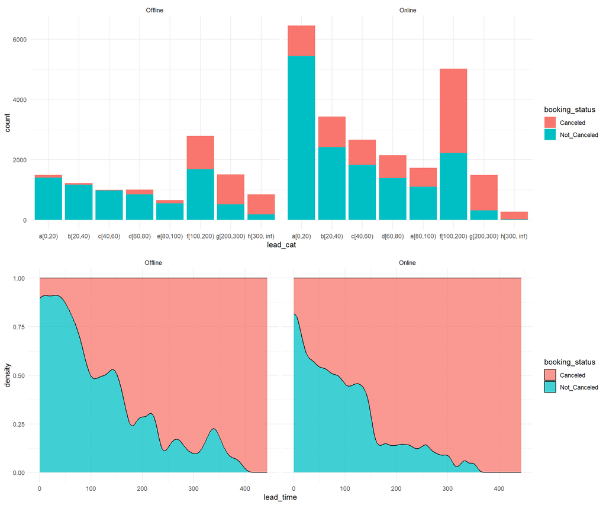

```r
plot1 <- ggplot(reserve, aes( x = lead_cat, fill = booking_status)) +
  geom_bar() +
  theme_minimal() +

  facet_wrap(vars(market_segment_type))

plot2 <-ggplot(reserve, aes(x = lead_time, fill= booking_status)) +
  geom_density(position = "fill", alpha = .75) +
  theme_minimal()+
  facet_wrap(vars(market_segment_type))

yonline <- reserve %>% filter( market_segment_type == "Online") %>%   tabyl(booking_status, lead_cat)%>%
adorn_totals("col") %>%
  adorn_percentages("col") %>%
  adorn_pct_formatting(digits = 1) %>%
  adorn_ns %>%
  gt()

nonline <- reserve %>% filter( market_segment_type == "Offline") %>%   tabyl(booking_status, lead_cat)%>%
adorn_totals("col") %>%
  adorn_percentages("col") %>%
  adorn_pct_formatting(digits = 1) %>%
  adorn_ns %>%
  gt()

grid.arrange(plot1, plot2)
```

```r
yonline
```

| booking_status | a[0,20) | b[20,40) | c[40,60) | d[60,80) | e[80,100) | f[100,200) | g[200,300) | h[300, inf) | Total |
| --- | --- | --- | --- | --- | --- | --- | --- | --- | --- |
| Canceled | 15.6% (1005) | 29.5% (1011) | 31.5% (840) | 35.1% (755) | 36.5% (633) | 55.6% (2788) | 79.1% (1185) | 93.5% (258) | 36.5% (8475) |
| Not_Canceled | 84.4% (5441) | 70.5% (2417) | 68.5% (1828) | 64.9% (1393) | 63.5% (1099) | 44.4% (2229) | 20.9% (314) | 6.5% (18) | 63.5% (14739) |

```r
nonline
```

| booking_status | a[0,20) | b[20,40) | c[40,60) | d[60,80) | e[80,100) | f[100,200) | g[200,300) | h[300, inf) | Total |
| --- | --- | --- | --- | --- | --- | --- | --- | --- | --- |
| Canceled | 5.6% (84) | 3.8% (47) | 1.9% (19) | 15.8% (159) | 15.3% (101) | 39.4% (1098) | 65.5% (989) | 77.5% (656) | 29.9% (3153) |
| Not_Canceled | 94.4% (1411) | 96.2% (1176) | 98.1% (983) | 84.2% (848) | 84.7% (557) | 60.6% (1688) | 34.5% (522) | 22.5% (190) | 70.1% (7375) |

## Final Summary (10 points)

> *Summarize your research question and findings below.*

> Based on my original question if the change in reservation time increases the probability of cancelling, it appears that the odds of observing a cancellation increases the earlier the reservation was made. This is true for whether it was booked online or offline as well.

> *Are your findings what you expected? Why or Why not?*

> The finding are what I expected, although I did not do any analysis on the data itself besides observation. I am assuming you would do a regression analysis on probability? A risk analysis of something occurring over time?

> I also could also only show that there appears to be a positive trend in cancellations over time, but can’t explain why this occurs.